# 📈 **Regresión Lineal**

### Actividad con Scikit-learn

### Versión Adaptada: Dr. Hugo García Tecocoatzi

### Rafael Santamaria Heredia | A01646667

**En Machine Learning y en este notebook vamos a usar Scikit-learn**

[figure not shown]

### **¿Para qué se usa scikit-learn?**

Scikit-learn (Sklearn) es la biblioteca más útil y robusta para machine learning en Python. Proporciona una selección de herramientas eficientes para machine learning y modelado estadístico que incluyen clasificación, regresión, agrupamiento y reducción de dimensionalidad a través de una interfaz consistente en Python.

En esta ocasión lo usaremos para entrenar un modelo de regresión lineal

#### **¿Para qué se usa la regresión lineal?**

El análisis de regresión lineal se usa para predecir el valor de una variable basándose en el valor de otra variable. La variable que deseas predecir se llama variable dependiente. La variable que usas para predecir el valor de la otra variable se llama variable independiente (predictora).

# **Haciendo predicciones con una Regresión Lineal**

Dado que la representación es una ecuación lineal, hacer predicciones es tan simple como resolver la ecuación para un conjunto específico de entradas.

Vamos a hacer esto concreto con un ejemplo. Imagina que estamos prediciendo el peso (y) a partir de la altura (x). Nuestra representación del modelo de regresión lineal para este problema sería:

**y = B0 + B1 * x1**

o

**peso = B0 + B1 * altura**

Donde B0 es el coeficiente de sesgo y B1 es una razón que relaciona el peso y la altura. Usamos una técnica de machine learning para encontrar un buen conjunto de valores de coeficientes. Una vez encontrados, podemos introducir diferentes valores de altura para predecir el peso.

Por ejemplo, usemos B0 = 0.1 y B1 = 0.5. Vamos a introducirlos y calcular el peso (en kilogramos) para una persona con una altura de 182 centímetros.

peso = 0.1 + 0.5 * 182

peso = 91.1

Puedes ver que la ecuación anterior podría representarse como una línea en dos dimensiones. B0 es nuestro punto de partida independientemente de la altura que tengamos. Podemos recorrer un montón de alturas de 100 a 250 centímetros e introducirlas en la ecuación y obtener valores de peso, creando nuestra línea.

[figure not shown]

Ahora que sabemos cómo hacer predicciones dado un modelo de regresión lineal aprendido, veamos algunas reglas generales para preparar nuestros datos y aprovechar al máximo este tipo de modelo.

## 📤 Importar e Instalar Bibliotecas

```python
!pip install hvplot
```

```python
import pandas as pd
import numpy as np
import matplotlib.pyplot as plt
import seaborn as sns
import hvplot.pandas

from sklearn.model_selection import train_test_split

from sklearn import metrics

from sklearn.linear_model import LinearRegression

%matplotlib inline
```

### 💾 Explorar los Datos

```python
df=pd.read_csv('/content/drive/MyDrive/NOTEBOOKS PYTHON/Realestate.csv')
```

```python
df.head()
```

|  | No | X1 transaction date | X2 house age | X3 distance to the nearest MRT station | X4 number of convenience stores | X5 latitude | X6 longitude | Y house price of unit area |
| --- | --- | --- | --- | --- | --- | --- | --- | --- |
| 0 | 1 | 2012.917 | 32.0 | 84.87882 | 10 | 24.98298 | 121.54024 | 37.9 |
| 1 | 2 | 2012.917 | 19.5 | 306.59470 | 9 | 24.98034 | 121.53951 | 42.2 |
| 2 | 3 | 2013.583 | 13.3 | 561.98450 | 5 | 24.98746 | 121.54391 | 47.3 |
| 3 | 4 | 2013.500 | 13.3 | 561.98450 | 5 | 24.98746 | 121.54391 | 54.8 |
| 4 | 5 | 2012.833 | 5.0 | 390.56840 | 5 | 24.97937 | 121.54245 | 43.1 |

Tenemos los precios en dólar por unidad de área de casas en Real Estate.

```python
df.shape
```

```
(414, 8)
```

```python
df.info()
```

```
<class 'pandas.core.frame.DataFrame'>
RangeIndex: 414 entries, 0 to 413
Data columns (total 8 columns):
 #   Column                                  Non-Null Count  Dtype
---  ------                                  --------------  -----
 0   No                                      414 non-null    int64
 1   X1 transaction date                     414 non-null    float64
 2   X2 house age                            414 non-null    float64
 3   X3 distance to the nearest MRT station  414 non-null    float64
 4   X4 number of convenience stores         414 non-null    int64
 5   X5 latitude                             414 non-null    float64
 6   X6 longitude                            414 non-null    float64
 7   Y house price of unit area              414 non-null    float64
dtypes: float64(6), int64(2)
memory usage: 26.0 KB
```

```python
df.corr()
```

|  | No | X1 transaction date | X2 house age | X3 distance to the nearest MRT station | X4 number of convenience stores | X5 latitude | X6 longitude | Y house price of unit area |
| --- | --- | --- | --- | --- | --- | --- | --- | --- |
| No | 1.000000 | -0.048658 | -0.032808 | -0.013573 | -0.012699 | -0.010110 | -0.011059 | -0.028587 |
| X1 transaction date | -0.048658 | 1.000000 | 0.017549 | 0.060880 | 0.009635 | 0.035058 | -0.041082 | 0.087491 |
| X2 house age | -0.032808 | 0.017549 | 1.000000 | 0.025622 | 0.049593 | 0.054420 | -0.048520 | -0.210567 |
| X3 distance to the nearest MRT station | -0.013573 | 0.060880 | 0.025622 | 1.000000 | -0.602519 | -0.591067 | -0.806317 | -0.673613 |
| X4 number of convenience stores | -0.012699 | 0.009635 | 0.049593 | -0.602519 | 1.000000 | 0.444143 | 0.449099 | 0.571005 |
| X5 latitude | -0.010110 | 0.035058 | 0.054420 | -0.591067 | 0.444143 | 1.000000 | 0.412924 | 0.546307 |
| X6 longitude | -0.011059 | -0.041082 | -0.048520 | -0.806317 | 0.449099 | 0.412924 | 1.000000 | 0.523287 |
| Y house price of unit area | -0.028587 | 0.087491 | -0.210567 | -0.673613 | 0.571005 | 0.546307 | 0.523287 | 1.000000 |

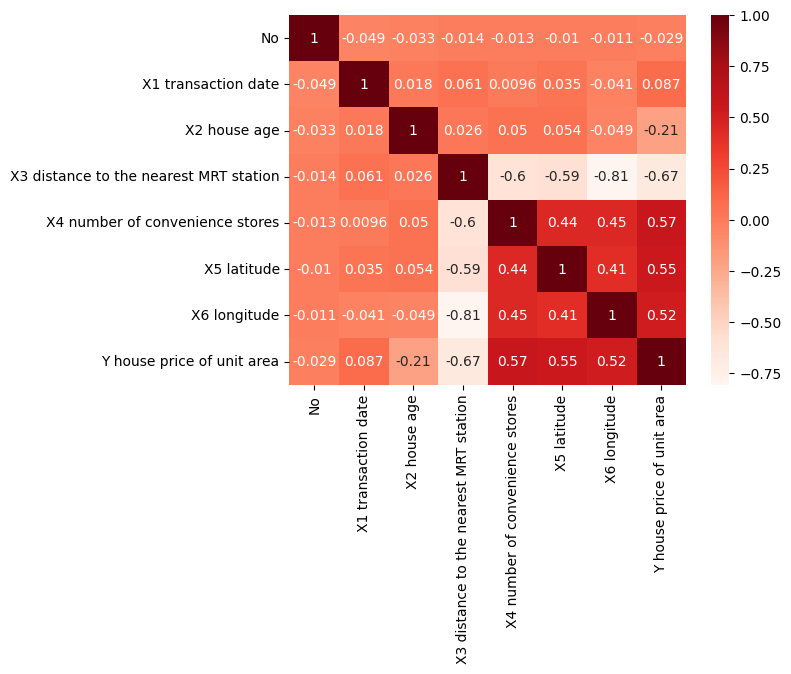

```python
sns.heatmap(df.corr(), annot=True,cmap='Reds')
plt.show()
```

1. Describe qué información lees de esto.
2. ¿Cuáles son las variables fuertemente correlacionadas?
3. ¿Te hacen sentido?

**Respuesta:**

1. La tabla y el mapa de calor muestran qué tanto se relaciona cada variable con las demás, y en especial con el precio de la casa (Y). Los valores van de -1 a 1: mientras más cerca de 1 o de -1, más fuerte es la relación; cerca de 0 significa que casi no hay relación.
2. Las variables que más se relacionan con el precio son:
   - Distancia a la estación de metro (X3): relación negativa fuerte (-0.67) → entre más lejos del metro, más bajo el precio.
   - Número de tiendas de conveniencia cercanas (X4): relación positiva (+0.57).
   - Latitud (X5): relación positiva (+0.55).
   - Longitud (X6): relación positiva (+0.52).

   También hay relaciones fuertes entre las variables de ubicación, por ejemplo la distancia al metro con la longitud (-0.81).
3. Sí tienen sentido. Entre más cerca del metro y más tiendas de conveniencia haya, normalmente es una zona más urbana y con más demanda, así que el precio sube. Y como la distancia al metro depende de dónde está ubicada la casa, es lógico que también se relacione con la latitud y la longitud.

### 📊 Análisis Exploratorio de Datos (EDA)

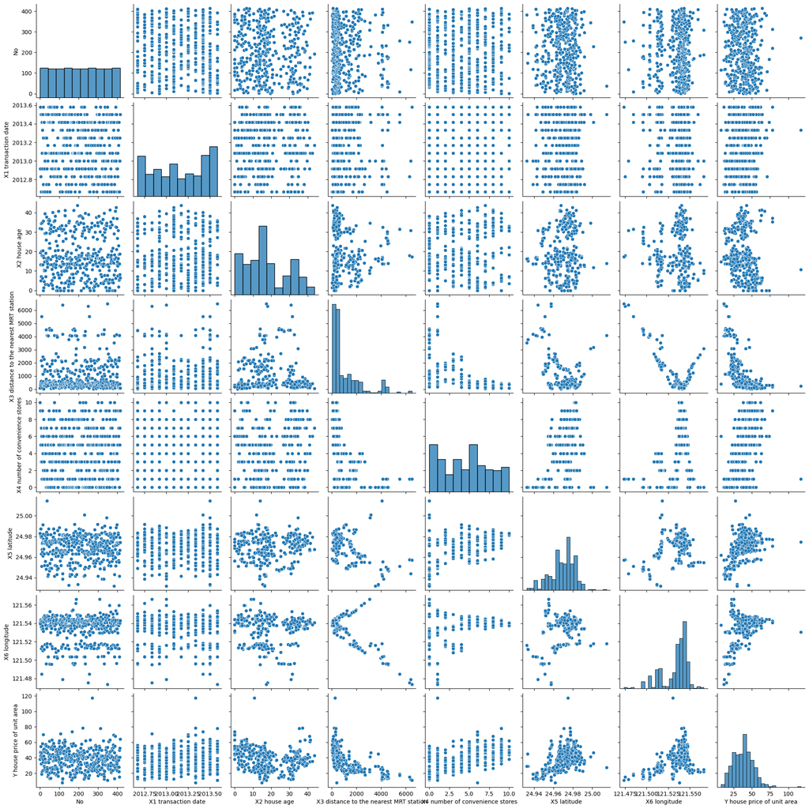

```python
sns.pairplot(df)
plt.show()
```

4. Con base en la correlación y estas gráficas, ¿qué variables pueden modelarse con una regresión lineal?

**Respuesta:**

4. La matriz de correlación señala que X3 (distancia al metro), X4 (tiendas de conveniencia), X5 (latitud) y X6 (longitud) son las que más se relacionan con el precio, pero el pairplot deja ver detalles que los números solos no muestran:
- **X3 (distancia al metro) vs Y**: los puntos forman una curva que baja rápido al principio y luego se aplana, no una línea recta. Es la relación más fuerte de todas, pero al no ser perfectamente lineal, el modelo lineal podría no capturarla del todo bien.
- **X4 (tiendas de conveniencia) vs Y**: se nota una tendencia a que el precio suba conforme hay más tiendas cerca, aunque los puntos están dispersos porque X4 solo toma valores enteros (0 a 10).
- **X5 (latitud) y X6 (longitud) vs Y**: ambas muestran una tendencia creciente, pero más como una nube de puntos que como una línea clara.
- **X1 (fecha de transacción) y X2 (edad de la casa) vs Y**: los puntos no forman ninguna figura reconocible, solo una nube dispersa, lo que confirma que casi no aportan información para predecir el precio.

En conclusión, X3, X4, X5 y X6 siguen siendo las mejores candidatas para el modelo, pero el pairplot muestra que la relación de X3 con el precio no es totalmente lineal y que X3, X5 y X6 están capturando en parte la misma información de ubicación. X1 y X2 se pueden dejar fuera o como variables secundarias, ya que no muestran ningún patrón claro con el precio.

### 📈 Entrenando un Modelo de Regresión Lineal

#### Arrays X y Y

```python
X=df.drop('Y house price of unit area', axis=1)

y=df['Y house price of unit area']
```

```python
print("X=",X.shape,"\ny=", y.shape)
```

```
X= (414, 7)
y= (414,)
```

### 🧱 División de los datos: Entrenamiento y Prueba

Ahora dividamos los datos en un conjunto de entrenamiento y un conjunto de prueba. Entrenaremos nuestro modelo en el conjunto de entrenamiento y luego usaremos el conjunto de prueba para evaluar el modelo.

```python
X_train, X_test, y_train, y_test = train_test_split(X, y, test_size=0.3, random_state=101)
```

```python
X_train.shape
```

```
(289, 7)
```

```python
X_test.shape
```

```
(125, 7)
```

### Ahora vamos a usar la función predeterminada de Scikit-learn: LinearRegression()

```python
model = LinearRegression()
```

```python
model.fit(X_train, y_train)
```

```
LinearRegression()
```

#### Evaluación del modelo

```python
model.coef_
```

```
array([-2.92429686e-03,  4.68668437e+00, -2.75675355e-01, -4.24850544e-03,
        1.17832502e+00,  2.40947692e+02,  1.86694591e+01])
```

```python
pd.DataFrame(model.coef_, X.columns, columns=['Coeficientes'])
```

|  | Coeficientes |
| --- | --- |
| No | -0.002924 |
| X1 transaction date | 4.686684 |
| X2 house age | -0.275675 |
| X3 distance to the nearest MRT station | -0.004249 |
| X4 number of convenience stores | 1.178325 |
| X5 latitude | 240.947692 |
| X6 longitude | 18.669459 |

5. Regresa a la pregunta 4, y ve si los coeficientes corresponden la figura.
6. ¿Cómo se interpreta cada coeficiente?

**Respuesta:**

5. Sí corresponden. Las variables que en la pregunta 4 identificamos como más relacionadas con el precio (X3, X4, X5 y X6) son justo las que tienen coeficientes con el signo esperado: negativo para la distancia al metro, y positivo para las tiendas de conveniencia, la latitud y la longitud. Los coeficientes de latitud y longitud se ven enormes (240 y 18), pero eso es porque estas variables cambian muy poquito entre una casa y otra (son grados de coordenada), no porque sean "más importantes" que las demás.
6. Cada coeficiente indica cuánto sube o baja el precio cuando esa variable aumenta en una unidad, dejando las demás iguales:
   - Edad de la casa: por cada año más de antigüedad, el precio baja un poco (alrededor de 0.28).
   - Distancia al metro: por cada metro más de distancia, el precio baja muy poquito (alrededor de 0.004), pero como las distancias son de cientos o miles de metros, el efecto final sí es grande.
   - Tiendas de conveniencia: cada tienda extra cercana sube el precio en promedio alrededor de 1.18.
   - Latitud y longitud: cambian muy poco de una casa a otra, por eso su coeficiente es tan grande (solo compensa esa escala pequeña), pero en la práctica reflejan que la ubicación sí influye mucho en el precio.

### Predicciones del modelo

```python
y_pred = model.predict(X_test)
```

## ✔️ Métricas de Evaluación de Regresión

Aquí están las tres métricas de evaluación más comunes para problemas de regresión:

> - **Error Absoluto Medio (MAE)** es la media del valor absoluto de los errores: $$\frac 1n\sum_{i=1}^n|y_i-\hat{y}_i|$$
> - **Error Cuadrático Medio (MSE)** es la media de los errores al cuadrado: $$\frac 1n\sum_{i=1}^n(y_i-\hat{y}_i)^2$$
> - **Raíz del Error Cuadrático Medio (RMSE)** es la raíz cuadrada de la media de los errores al cuadrado: $$\sqrt{\frac 1n\sum_{i=1}^n(y_i-\hat{y}_i)^2}$$

> Comparando estas métricas:
> - **MAE** es la más fácil de entender, porque es el error promedio.
> - **MSE** es más popular que MAE, porque MSE "castiga" los errores más grandes, lo que tiende a ser útil en el mundo real.
> - **RMSE** es aún más popular que MSE, porque RMSE es interpretable en las unidades de "y".

> Todas estas son **funciones de pérdida**, porque queremos minimizarlas.

```python
MAE= metrics.mean_absolute_error(y_test, y_pred)
MSE=metrics.mean_squared_error(y_test, y_pred)
RMSE= np.sqrt(MSE)
```

```python
MAE
```

```
5.373024532571052
```

```python
MSE
```

```
45.88030742874099
```

```python
RMSE
```

```
np.float64(6.773500382279534)
```

## **Histograma de Residuos**

- **A menudo, para la Regresión Lineal, es una buena idea evaluar los residuos $$(y-\hat{y})$$ por separado y no solo calcular métricas de rendimiento (ej. RMSE).**
- **Exploremos por qué esto es importante...**
- **Los errores residuales deberían ser aleatorios y aproximarse a una distribución normal.**

[figure not shown]

```python
test_residual= y_test - y_pred
```

```python
pd.DataFrame({'Error Values': (test_residual)}).hvplot.kde()
```

[output not shown]

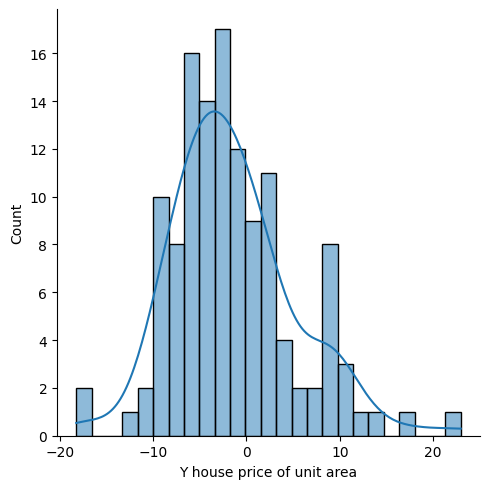

```python
sns.displot(test_residual, bins=25, kde=True)
plt.show()
```

- **El gráfico de residuos muestra el error residual vs. el valor verdadero de y.**

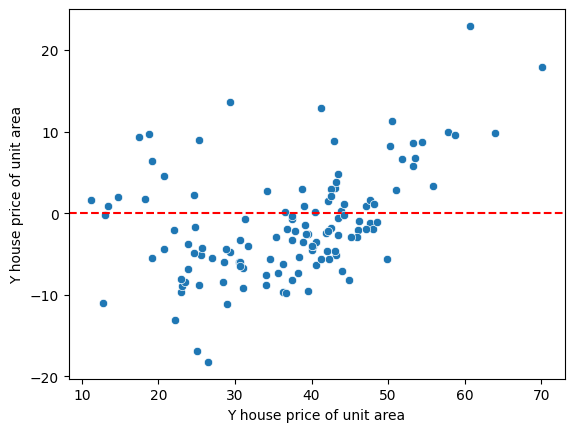

```python
sns.scatterplot(x=y_test, y=test_residual)

plt.axhline(y=0, color='r', ls='--')
plt.show()
```